# Unit 4 Assignment Voting

Vinyas

16 May 2016

##### Loading data

```r
gerber=read.csv("Data Files/gerber.csv")
summary(gerber)
```

```
##       sex              yob           voting         hawthorne
##  Min.   :0.0000   Min.   :1900   Min.   :0.0000   Min.   :0.000
##  1st Qu.:0.0000   1st Qu.:1947   1st Qu.:0.0000   1st Qu.:0.000
##  Median :0.0000   Median :1956   Median :0.0000   Median :0.000
##  Mean   :0.4993   Mean   :1956   Mean   :0.3159   Mean   :0.111
##  3rd Qu.:1.0000   3rd Qu.:1965   3rd Qu.:1.0000   3rd Qu.:0.000
##  Max.   :1.0000   Max.   :1986   Max.   :1.0000   Max.   :1.000
##    civicduty        neighbors          self           control
##  Min.   :0.0000   Min.   :0.000   Min.   :0.0000   Min.   :0.0000
##  1st Qu.:0.0000   1st Qu.:0.000   1st Qu.:0.0000   1st Qu.:0.0000
##  Median :0.0000   Median :0.000   Median :0.0000   Median :1.0000
##  Mean   :0.1111   Mean   :0.111   Mean   :0.1111   Mean   :0.5558
##  3rd Qu.:0.0000   3rd Qu.:0.000   3rd Qu.:0.0000   3rd Qu.:1.0000
##  Max.   :1.0000   Max.   :1.000   Max.   :1.0000   Max.   :1.0000
```

##### What proportion of people in this dataset voted in this election?

```r
as.numeric(table(gerber$voting)[2]/nrow(gerber))
```

```
## [1] 0.3158996
```

##### Which of the four “treatment groups” had the largest percentage of people who actually voted (voting = 1)?

```r
tapply(gerber$voting, gerber$civicduty, mean)
```

```
##         0         1
## 0.3160698 0.3145377
```

```r
tapply(gerber$voting, gerber$hawthorne, mean)
```

```
##         0         1
## 0.3150909 0.3223746
```

```r
tapply(gerber$voting, gerber$self, mean)
```

```
##         0         1
## 0.3122446 0.3451515
```

```r
tapply(gerber$voting, gerber$neighbors, mean)
```

```
##         0         1
## 0.3081505 0.3779482
```

#### Logistic regression model

```r
gerber_model=glm(voting~hawthorne+civicduty+neighbors+self,data=gerber,family = binomial)
summary(gerber_model)
```

```
##
## Call:
## glm(formula = voting ~ hawthorne + civicduty + neighbors + self,
##     family = binomial, data = gerber)
##
## Deviance Residuals:
##     Min       1Q   Median       3Q      Max
## -0.9744  -0.8691  -0.8389   1.4586   1.5590
##
## Coefficients:
##              Estimate Std. Error  z value Pr(>|z|)
## (Intercept) -0.863358   0.005006 -172.459  < 2e-16 ***
## hawthorne    0.120477   0.012037   10.009  < 2e-16 ***
## civicduty    0.084368   0.012100    6.972 3.12e-12 ***
## neighbors    0.365092   0.011679   31.260  < 2e-16 ***
## self         0.222937   0.011867   18.786  < 2e-16 ***
## ---
## Signif. codes:  0 '***' 0.001 '**' 0.01 '*' 0.05 '.' 0.1 ' ' 1
##
## (Dispersion parameter for binomial family taken to be 1)
##
##     Null deviance: 429238  on 344083  degrees of freedom
## Residual deviance: 428090  on 344079  degrees of freedom
## AIC: 428100
##
## Number of Fisher Scoring iterations: 4
```

```r
predict_voting=predict(gerber_model,type="response")

table(gerber$voting,predict_voting>0.3)
```

```
##
##      FALSE   TRUE
##   0 134513 100875
##   1  56730  51966
```

```r
sum(diag(table(gerber$voting,predict_voting>0.3)))/nrow(gerber) #Accuracy
```

```
## [1] 0.5419578
```

```r
library(ROCR)
ROCRpred=prediction(predict_voting,gerber$voting)
as.numeric(performance(ROCRpred,"auc")@y.values)
```

```
## [1] 0.5308461
```

```r
#Even though all of our variables are significant, our model does not improve over the baseline model of just predicting that someone will not vote, and the AUC is low. So while the treatment groups do make a difference, this is a weak predictive model.
```

###### Build a CART tree for voting using all data and the same four treatment variables we used before. Don’t set the option method=“class” - we are actually going to create a regression tree here. We are interested in building a tree to explore the fraction of people who vote, or the probability of voting.

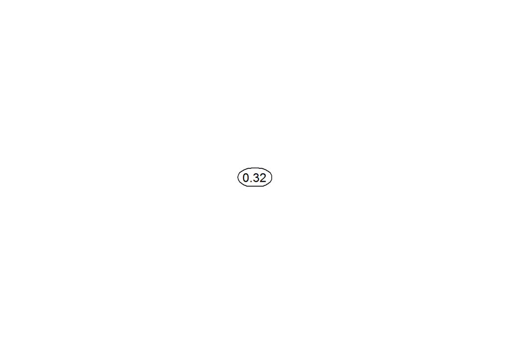

```r
library(rpart)
library(rpart.plot)
CARTmodel = rpart(voting ~ civicduty + hawthorne + self + neighbors, data=gerber)
prp(CARTmodel)
```

```r
#you should just see one leaf! There are no splits in the tree, because none of the variables make a big enough effect to be split on.
```

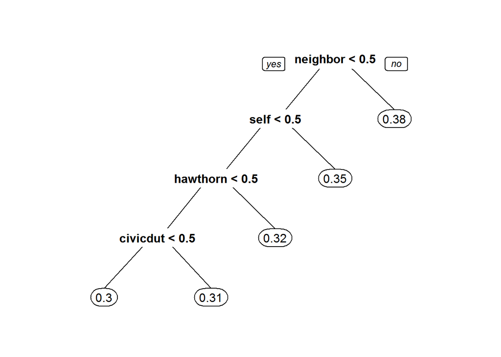

```r
#force the complete tree to be built

CARTmodel2 = rpart(voting ~ civicduty + hawthorne + self + neighbors, data=gerber, cp=0.0)
prp(CARTmodel2)
```

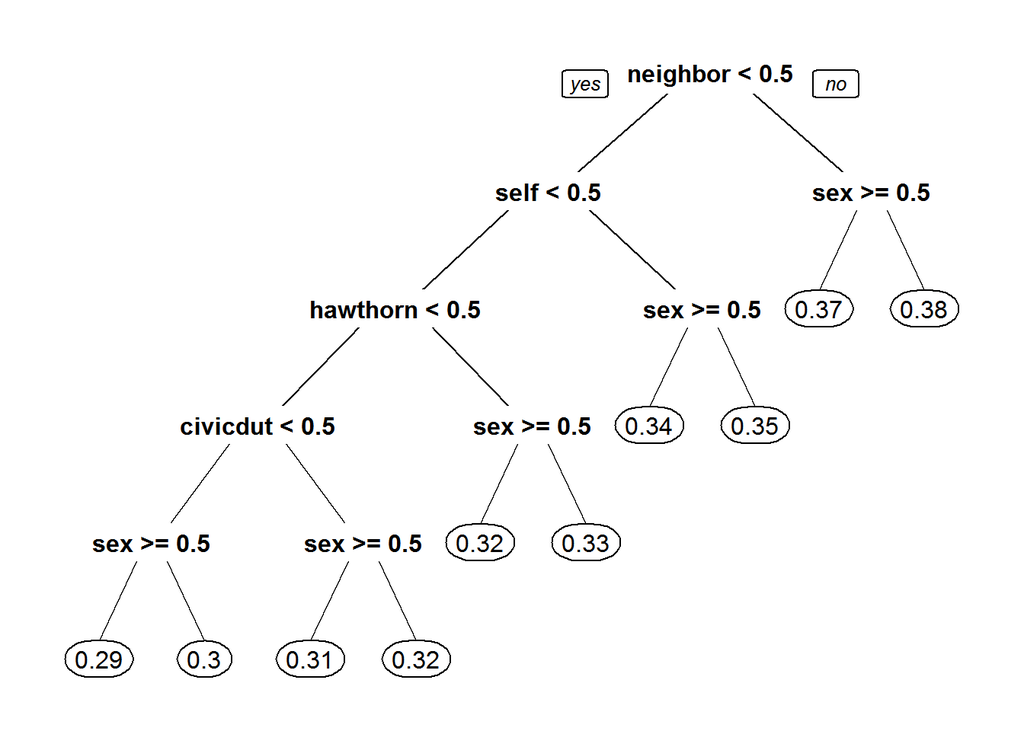

```r
#NEw model with the variable sex added
CARTmodel3 = rpart(voting ~ civicduty + hawthorne + self + neighbors + sex, data=gerber, cp=0.0)
prp(CARTmodel3)
```

##### Make new models, one with only control as independent var and second with control and sex

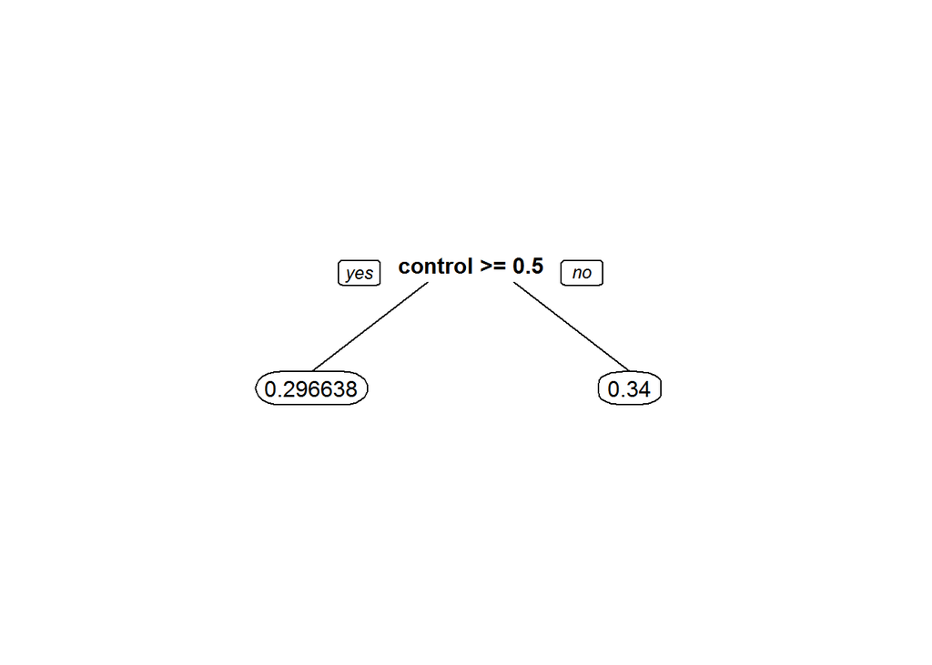

```r
CARTmodel4 = rpart(voting ~ control, data=gerber, cp=0.0)
CARTmodel5 = rpart(voting ~ control+sex, data=gerber, cp=0.0)

prp(CARTmodel4,digits=6)
```

```r
abs(0.296638-0.34)
```

```
## [1] 0.043362
```

##### create a logistic regression model using “sex” and “control”. Interpret the coefficient for “sex”

```r
gerber_model2=glm(voting~control+sex,data=gerber,family = binomial)
summary(gerber_model2)
```

```
##
## Call:
## glm(formula = voting ~ control + sex, family = binomial, data = gerber)
##
## Deviance Residuals:
##     Min       1Q   Median       3Q      Max
## -0.9220  -0.9012  -0.8290   1.4564   1.5717
##
## Coefficients:
##              Estimate Std. Error z value Pr(>|z|)
## (Intercept) -0.635538   0.006511 -97.616  < 2e-16 ***
## control     -0.200142   0.007364 -27.179  < 2e-16 ***
## sex         -0.055791   0.007343  -7.597 3.02e-14 ***
## ---
## Signif. codes:  0 '***' 0.001 '**' 0.01 '*' 0.05 '.' 0.1 ' ' 1
##
## (Dispersion parameter for binomial family taken to be 1)
##
##     Null deviance: 429238  on 344083  degrees of freedom
## Residual deviance: 428443  on 344081  degrees of freedom
## AIC: 428449
##
## Number of Fisher Scoring iterations: 4
```

```r
#you can see that the coefficient for the "sex" variable is -0.055791. This means that women are less likely to vote, since women have a larger value in the sex variable, and a negative coefficient means that larger values are predictive of 0.

Possibilities = data.frame(sex=c(0,0,1,1),control=c(0,1,0,1))
predict(gerber_model2, newdata=Possibilities, type="response")
```

```
##         1         2         3         4
## 0.3462559 0.3024455 0.3337375 0.2908065
```

##### We’re going to add a new term to our logistic regression now, that is the combination of the “sex” and “control” variables - so if this new variable is 1, that means the person is a woman AND in the control group

```r
gerber_model3=glm(voting~sex+control+sex:control,data = gerber,family='binomial')
summary(gerber_model3)
```

```
##
## Call:
## glm(formula = voting ~ sex + control + sex:control, family = "binomial",
##     data = gerber)
##
## Deviance Residuals:
##     Min       1Q   Median       3Q      Max
## -0.9213  -0.9019  -0.8284   1.4573   1.5724
##
## Coefficients:
##              Estimate Std. Error z value Pr(>|z|)
## (Intercept) -0.637471   0.007603 -83.843  < 2e-16 ***
## sex         -0.051888   0.010801  -4.804 1.55e-06 ***
## control     -0.196553   0.010356 -18.980  < 2e-16 ***
## sex:control -0.007259   0.014729  -0.493    0.622
## ---
## Signif. codes:  0 '***' 0.001 '**' 0.01 '*' 0.05 '.' 0.1 ' ' 1
##
## (Dispersion parameter for binomial family taken to be 1)
##
##     Null deviance: 429238  on 344083  degrees of freedom
## Residual deviance: 428442  on 344080  degrees of freedom
## AIC: 428450
##
## Number of Fisher Scoring iterations: 4
```

```r
#This coefficient is negative, so that means that a value of 1 in this variable decreases the chance of voting. This variable will have variable 1 if the person is a woman and in the control group.
```

```r
predict(gerber_model3, newdata=Possibilities, type="response")
```

```
##         1         2         3         4
## 0.3458183 0.3027947 0.3341757 0.2904558
```

```r
#The logistic regression model now predicts 0.2904558 for the (Woman, Control) case, so there is now a very small difference (practically zero) between CART and logistic regression.
```

###### We should not use all possible interaction terms in a logistic regression model due to overfitting. Even in this simple problem, we have four treatment groups and two values for sex. If we have an interaction term for every treatment variable with sex, we will double the number of variables. In smaller data sets, this could quickly lead to overfitting.